# Welcome to Minicourse #12

JMM 2019

## Participants

## Hello, my name is …

Take a moment to introduce yourself

- to **at least THREE** people,
- who are sitting **near you**, but
- whom you **do not already know**.

Things you might share about yourself:

- name, institution,
- why you are in this minicourse
- favorite hobby
- something on the JMM program you are looking forward to

## How much have we used R?

[figure not shown]

```r
library(ggformula)
gf_counts(~ R.prof, data = S, fill = ~ course)
```

## How much have we used tidyverse?

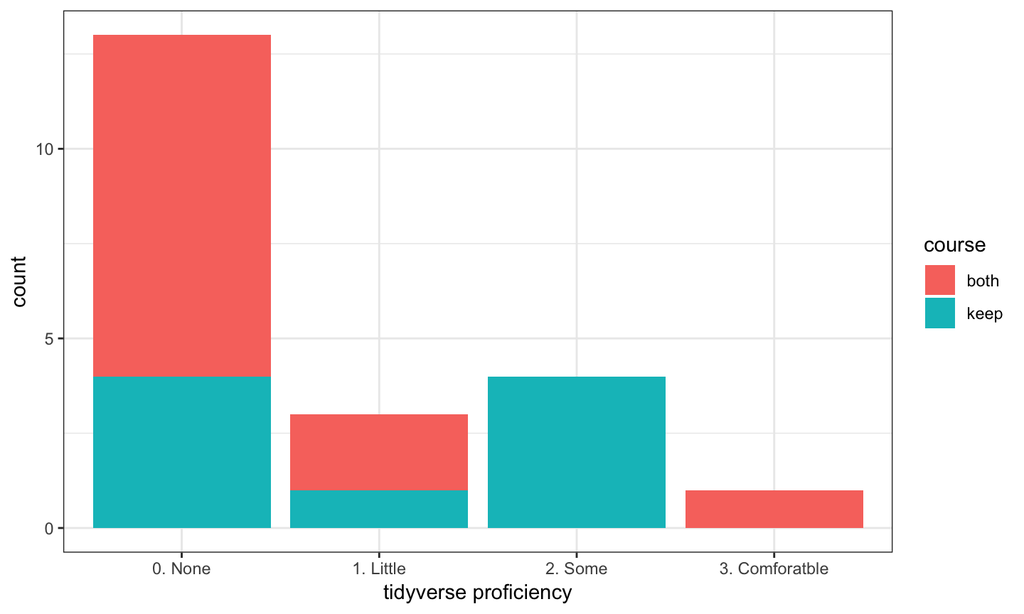

```r
library(ggformula)
gf_counts(~ tidyverse.prof, data = S, fill = ~ course)
```

## When do we fill out surveys?

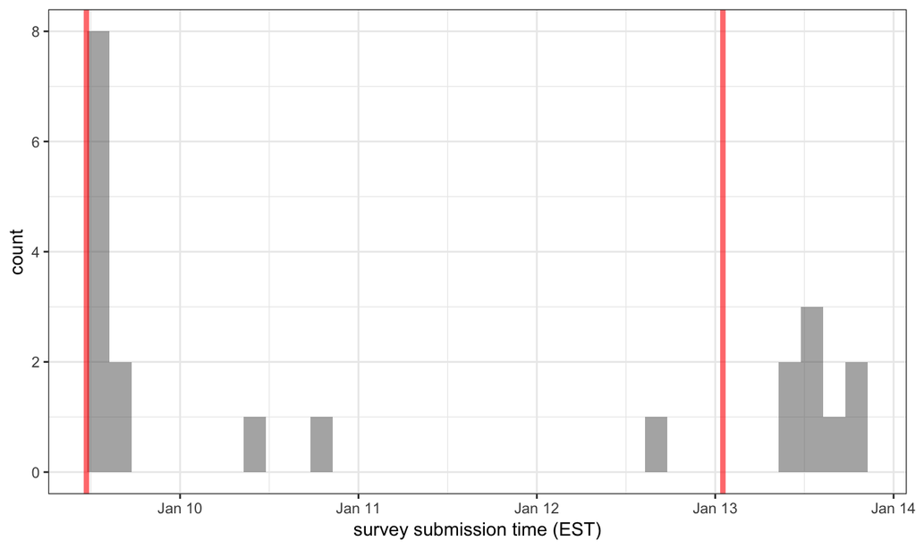

```r
library(ggformula)
gf_histogram( ~ time, data = S)
```

## When do we fill out surveys?

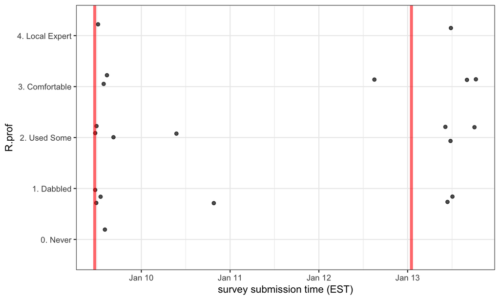

```r
library(ggformula)
gf_jitter(R.prof ~ time, data = S)
```

## Presenters/Facilitators

## Shonda Kuiper, Grinnel College

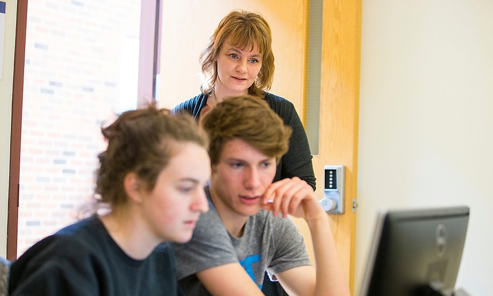

## Randall Pruim, Calvin College

[figure not shown]

## What is tidyverse?

## Less Volume, More Creativity

“Less Volume, More Creativity” can serve as a guiding principle to select and R toolkit that is

- small (fewer commands/ideas/structures is better)
- coherant (components play well together)
- powerful (gets the job done)

### Examples

- `mosaic` (and `ggformula`) for numerical and graphical summaries, modeling
- `R Markdown` for document creation
- `dplyr`/`tidyverse` for data transformation

## What is tidyverse?

- A collection of packages by Hadley Wickham (and friends)
  - goal: solve important data analysis problems in a coherent, systematic way
- `dplyr` and `tidyr`: parts of this toolkit devoted to data transformation
  - useful for preparing “found data” for your students
  - useful for combining data from multiple sources
  - useful for rearranging data to make it more convenient to work with
- `tidyverse` is quite large, but its components can be added one by one, and since they play well together, the marginal cost of adding a new tools to the toolkit is low.

## Let’s give it a try

Running the `learnr` tutorial

- links available at https://rpruim.github.io/JMM2019/
- interactive tutorials available on two servers (at Calvin and at RStudio)
- also links to the source (Rmd) file that you can download and run locally
  - avoid network latency issues
  - see how the tutorials are created
  - requires that `learnr` (and some other R packages) be installed on your system